# Homework 2: Regression Model Building

STAT 253

# Exercises

## 1: prepare & acquaint yourself with the data

```r
# Load packages
# (You might need to install ggridges)
library(ggridges) # for joy plots
library(tidymodels)
library(tidyverse)

# Load data
music <- read_csv("https://mac-stat.github.io/data/spotify_new.csv")
```

### Part a

Calculate the range of the observed `popularity` outcomes, calculating the minimum and the maximum.

**Answer**

There are multiple approaches; here are a few!

```r
# option 1 (my favorite)
music %>%
  summarize(min(popularity), max(popularity))
```

```
# A tibble: 1 × 2
  `min(popularity)` `max(popularity)`
              <dbl>             <dbl>
1                21                98
```

```r
# option 2
min(music$popularity)
```

```
[1] 21
```

```r
max(music$popularity)
```

```
[1] 98
```

```r
# option 3
music %>%
  summarize(range(popularity))
```

```
# A tibble: 2 × 1
  `range(popularity)`
                <dbl>
1                  21
2                  98
```

Note: some people define range to be the difference between the maximum and minimum values. I personally prefer to present the actual min/max values, and then someone could easily calculate the difference between them if they wanted. However, it’s not so easy to go the other direction!

### Part b

Print out only the artist, song title, and popularity score for the 6 most popular songs in the data set.

**Answer**

There are multiple approaches; here are two!

```r
# option 1
music %>%
  select(artist, title, popularity) %>%
  arrange(desc(popularity)) %>%
  head()
```

```
# A tibble: 6 × 3
  artist      title                                         popularity
  <chr>       <chr>                                              <dbl>
1 Post Malone Circles                                               98
2 Tyga        Ayy Macarena                                          91
3 Ed Sheeran  I Don't Care (with Justin Bieber)                     90
4 Post Malone Goodbyes (feat. Young Thug)                           90
5 Post Malone Sunflower - Spider-Man: Into the Spider-Verse         88
6 Post Malone Sunflower - Spider-Man: Into the Spider-Verse         87
```

```r
# option 2
# Note how slice_max deals with ties (provides you all of the rows)
music %>%
  select(artist, title, popularity) %>%
  slice_max(popularity, n = 6)
```

```
# A tibble: 8 × 3
  artist        title                                         popularity
  <chr>         <chr>                                              <dbl>
1 Post Malone   Circles                                               98
2 Tyga          Ayy Macarena                                          91
3 Ed Sheeran    I Don't Care (with Justin Bieber)                     90
4 Post Malone   Goodbyes (feat. Young Thug)                           90
5 Post Malone   Sunflower - Spider-Man: Into the Spider-Verse         88
6 Post Malone   Sunflower - Spider-Man: Into the Spider-Verse         87
7 Ariana Grande thank u, next                                         87
8 Post Malone   Better Now                                            87
```

### Part c

*Joy Division* is perhaps the *only* band to have a data visualization tool named after them. The “Joy plot” is inspired by the band’s album cover:

[figure not shown]

Just for fun, construct a joy plot for the popularity of the artists in our sample. Comment on two artists you find interesting (either because of their data or because you know them).

```r
ggplot(music, aes(x = popularity, y = artist)) +
  geom_density_ridges() +
  theme_ridges()
```

**Answer**

**COMMENTS:** The comments will vary from student to student, but there should be comment about the data as it relates to the graphic. The discussion should mention *two* artists, as indicated in the instructions.

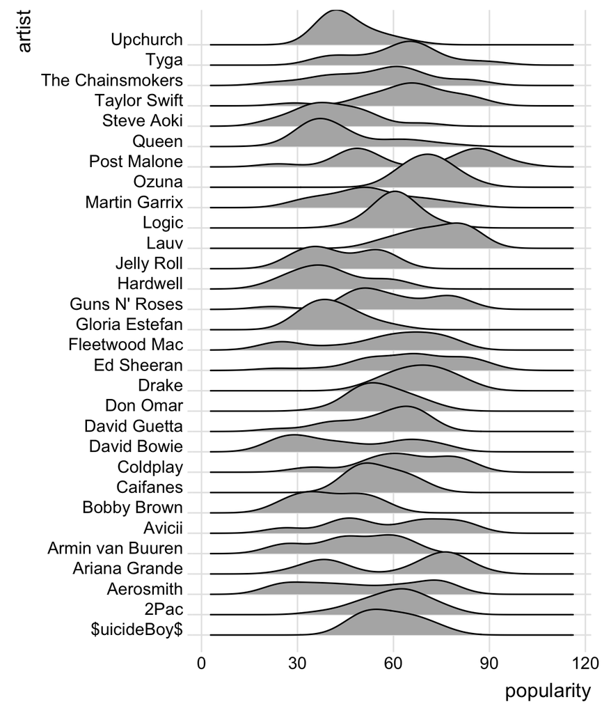

```r
ggplot(music, aes(x = popularity, y = artist)) +
  geom_density_ridges() +
  theme_ridges()
```

### Part d

Create a new data set `music_sub` which removes the following features which we either can’t or won’t use as predictors of popularity: `title` (can’t use), `album_name` (won’t use), `album_release` (won’t use), `mode` (won’t use), `artist` (won’t use).[^1]

**Answer**

As above, there are a few different ways to do this. In any case, you should end up with a dataset with 12 variables:

```r
music_sub <- music %>%
  select(-artist, -title, -album_name, -album_release, -mode)

# Note that you should end up with a data set with 12 variables
dim(music_sub)
```

```
[1] 662  12
```

```r
names(music_sub)
```

```
 [1] "popularity"       "genre"            "danceability"     "energy"
 [5] "loudness"         "speechiness"      "acousticness"     "instrumentalness"
 [9] "liveness"         "valence"          "tempo"            "duration_ms"
```

```r
# another option
music %>%
  select(-c(artist, title, album_name, album_release, mode))
```

```
# A tibble: 662 × 12
   popularity genre danceability energy loudness speechiness acousticness
        <dbl> <chr>        <dbl>  <dbl>    <dbl>       <dbl>        <dbl>
 1         98 pop          0.695  0.762    -3.50      0.0395      0.192
 2         91 pop          0.816  0.63     -5.57      0.226       0.133
 3         90 pop          0.798  0.675    -5.04      0.0442      0.0912
 4         90 latin        0.548  0.653    -3.88      0.081       0.456
 5         88 pop          0.76   0.479    -5.57      0.0466      0.556
 6         87 pop          0.755  0.522    -4.37      0.0575      0.533
 7         87 pop          0.717  0.653    -5.63      0.0658      0.229
 8         87 pop          0.68   0.578    -5.80      0.04        0.331
 9         86 pop          0.771  0.671    -5.62      0.0553      0.00929
10         86 latin        0.599  0.448    -6.31      0.0232      0.163
# ℹ 652 more rows
# ℹ 5 more variables: instrumentalness <dbl>, liveness <dbl>, valence <dbl>,
#   tempo <dbl>, duration_ms <dbl>
```

```r
# the following WON'T give you want you want
# this includes mode but not genre
music %>%
  select(where(is.numeric)) %>%
  head()
```

```
# A tibble: 6 × 12
  popularity danceability energy loudness  mode speechiness acousticness
       <dbl>        <dbl>  <dbl>    <dbl> <dbl>       <dbl>        <dbl>
1         98        0.695  0.762    -3.50     1      0.0395       0.192
2         91        0.816  0.63     -5.57     1      0.226        0.133
3         90        0.798  0.675    -5.04     1      0.0442       0.0912
4         90        0.548  0.653    -3.88     1      0.081        0.456
5         88        0.76   0.479    -5.57     1      0.0466       0.556
6         87        0.755  0.522    -4.37     1      0.0575       0.533
# ℹ 5 more variables: instrumentalness <dbl>, liveness <dbl>, valence <dbl>,
#   tempo <dbl>, duration_ms <dbl>
```

## 2: LASSO (part 1)

A small record label executive asks us to build a predictive model of `popularity` using the available set of predictors in `music_sub`. They don’t have a data team, hence prefer a simpler model. Let’s start by trying a LASSO model.

**IMPORTANT:**

- Each time you run a random process, use `set.seed(253)`.
- Support your answer to each part with R output.

### Part a

Build a reasonable, *final* LASSO model. You should try a range of **100 possible values** between $10^{-5}$ and $10^1$ for the $\lambda$ tuning parameter, and use 10-fold CV MAE to pick only **one** of these for your final model.

**Answer**

```r
# STEP 1: LASSO algorithm / model specification
lasso_spec <- linear_reg() %>%
  set_mode("regression") %>%
  set_engine("glmnet") %>%
  set_args(mixture = 1, penalty = tune())

# STEP 2: variable recipe
variable_recipe <- recipe(popularity ~ ., data = music_sub) %>%
  step_dummy(all_nominal_predictors())

# STEP 3: workflow specification (model + recipe)
lasso_workflow <- workflow() %>%
  add_recipe(variable_recipe) %>%
  add_model(lasso_spec)

# STEP 4: Estimate 100 LASSO models using different lambda values
# on a "grid" or range from 10^(-5) to 10^1.
set.seed(253)
lasso_models <- lasso_workflow %>%
  tune_grid(
    grid = grid_regular(penalty(range = c(-5, 1)), levels = 100),
    resamples = vfold_cv(music_sub, v = 10),
    metrics = metric_set(mae)
  )
```

**NOTE about STEP 4:** make sure students set a seed (to 253) and used the correct $\lambda$ grid! If not, their answers to all other questions below will not match the solutions.

NEXT STEPS: Pick $\lambda$ and fit final model.

If we want a balance between parsimony and prediction accuracy, we might pick the “parsimonious” lambda value:

```r
# Identify the parsimonious lambda value
parsimonious_penalty <- lasso_models %>%
  select_by_one_std_err(metric = "mae", desc(penalty))

# Finalize the model
final_lasso <- lasso_workflow %>%
  finalize_workflow(parameters = parsimonious_penalty) %>%
  fit(data = music_sub)
```

If you chose the “best” CV MAE instead, your code would look like this:

```r
# identify lambda with lowest CV MAE
best_penalty <- lasso_models %>%
  select_best(metric = "mae")

# fit final model
final_lasso_best <- lasso_workflow %>%
  finalize_workflow(parameters = best_penalty) %>%
  fit(data = music_sub)
```

Note: I generally recommend the first approach!

Also note: typically we do one *or* the other, not both! (For preceptors: if students used both `select_by_one_std_err` *and* `select_best` both, please leave them a comment prompting them to pick just one of these!)

### Part b

For reproducibility, report the exact value of $\lambda$ used in your final LASSO model.

**Answer**

**EXACT NUMBER:** $\lambda = 0.93$

```r
parsimonious_penalty
```

```
# A tibble: 1 × 2
  penalty .config
    <dbl> <chr>
1   0.933 pre0_mod083_post0
```

As mentioned above, the “parsimonious” approach is my preferred approach here.

If students instead chose to use the lambda with the “best” CV MAE their penalty will be:

```r
best_penalty
```

```
# A tibble: 1 × 2
  penalty .config
    <dbl> <chr>
1 0.00001 pre0_mod001_post0
```

### Part c

How many and which of the 11 original predictors remain in your final LASSO model?

**Answer**

**WHICH PREDICTORS:** danceability, energy, loudness, speechiness, genre (you might mention specifically pop, rap)

```r
final_lasso %>%
  tidy() %>%
  filter(estimate != 0) %>%  # this is useful to focus on the subset that are kept in
  mutate(estimate = round(estimate, 3)) # rounding the coefficient estimates for easier viewing
```

```
# A tibble: 7 × 3
  term         estimate penalty
  <chr>           <dbl>   <dbl>
1 (Intercept)    45.3     0.933
2 danceability   17.2     0.933
3 energy         -5.82    0.933
4 loudness        0.085   0.933
5 speechiness     3.95    0.933
6 genre_pop      11.5     0.933
7 genre_rap       0.009   0.933
```

For comparison, here are the results from using the “best” lambda instead. Note that we end up with a lot more variables in our model! (*Is this what we’d expect, given that the lambda value is closer to zero?*)

```r
final_lasso_best %>%
  tidy() %>%
  filter(estimate != 0) %>%
  mutate(estimate = round(estimate, 3))
```

```
# A tibble: 16 × 3
   term             estimate penalty
   <chr>               <dbl>   <dbl>
 1 (Intercept)        51.3   0.00001
 2 danceability       19.7   0.00001
 3 energy            -18.2   0.00001
 4 loudness            1.03  0.00001
 5 speechiness        12.4   0.00001
 6 acousticness       -1.84  0.00001
 7 instrumentalness   -0.592 0.00001
 8 liveness           -3.51  0.00001
 9 valence            -1.49  0.00001
10 tempo               0.007 0.00001
11 duration_ms         0     0.00001
12 genre_latin         6.38  0.00001
13 genre_pop          17.4   0.00001
14 genre_r.b           4.79  0.00001
15 genre_rap           5.77  0.00001
16 genre_rock          6.25  0.00001
```

### Part d

Report *and* interpret the CV MAE for your final LASSO model. Explain whether this is “big” or “small”, and support this with some context.

**Answer**

**INTERPRETATION:** CV MAE ~ 12.5. We estimate that the predictions of popularity for new songs will be off by 12.5 points on average. Considering the scale of popularity (which we showed to range from 21 to 98 in exercise 1), do you think this 12.5 MAE is large or small? (*Opinions may differ here! Just make sure you clearly justify your choice.*)

There are multiple “correct” wordings, but MAE interpretations should include:

- the outcome variable (popularity)
- units (points)
- the “M” part of MAE (eg “on average”)
- clarification that this is an out-of-sample metric (eg “new songs”)
- comparison to the range of possible outcomes when explaining whether the MAE is big or small

```r
# remind ourselves what the lambda is
# (and note that the value itself is stored in the penalty column)
parsimonious_penalty
```

```
# A tibble: 1 × 2
  penalty .config
    <dbl> <chr>
1   0.933 pre0_mod083_post0
```

```r
lasso_models %>%
  collect_metrics() %>%
  filter(penalty == parsimonious_penalty$penalty)
```

```
# A tibble: 1 × 7
  penalty .metric .estimator  mean     n std_err .config
    <dbl> <chr>   <chr>      <dbl> <int>   <dbl> <chr>
1   0.933 mae     standard    12.5    10   0.297 pre0_mod083_post0
```

Remember that if students chose the “best” approach, above, they will have a slightly lower MAE:

```r
# OR... if students used the "best" approach
lasso_models %>%
  collect_metrics() %>%
  filter(penalty == best_penalty$penalty)
```

```
# A tibble: 1 × 7
  penalty .metric .estimator  mean     n std_err .config
    <dbl> <chr>   <chr>      <dbl> <int>   <dbl> <chr>
1 0.00001 mae     standard    12.1    10   0.347 pre0_mod001_post0
```

## 3: LASSO (part 2)

You tuned the LASSO algorithm above, picking an appropriate value of $\lambda$ for your final LASSO model. Let’s think more about this tuning process.

### Part a

Construct a plot that illustrates the impact of $\lambda$ on the 10-fold CV MAE (and possibly 10-fold CV $R^2$). IMPORTANT: Take personal note of where *your* $\lambda$ falls into this plot, and ask yourself whether we tried a reasonable range for $\lambda$.

**Answer**

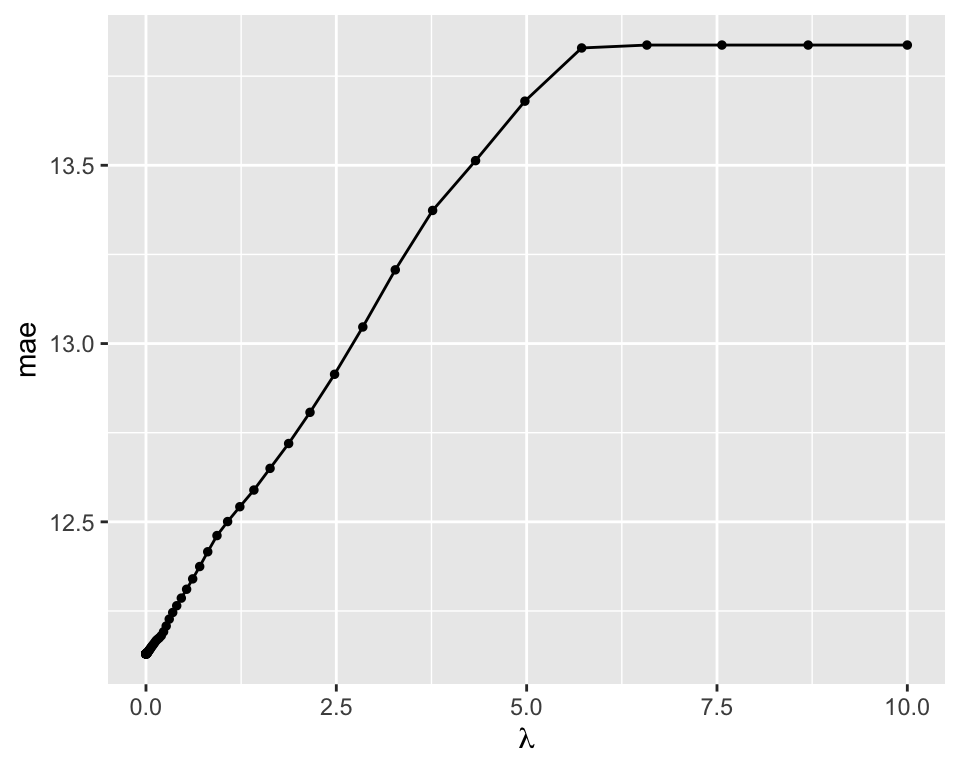

```r
autoplot(lasso_models) +
  scale_x_continuous() + # change the x-axis scale to plot lambda on original scale
  xlab(expression(lambda)) # label the x-axis
```

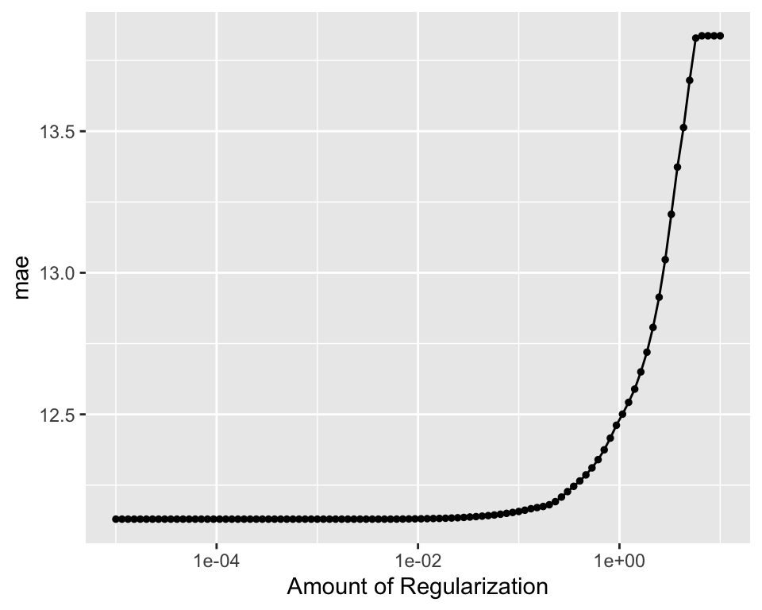

```r
# remember that if you leave off scale_x_continuous,
# your x-axis will be on the log10 scale
# (both are fine)
autoplot(lasso_models)
```

Note that our lambda value, 0.933 lies pretty far to the left of the range of values for $\lambda$. (In the case of the “best” lambda, 0 it’s actually the lowest $\lambda$ we tried!)

Perhaps trying more small (closer to zero) and fewer large (e.g., $> 5$) $\lambda$ values might have been helpful? It’s hard to see the “Goldilocks” problem from this plot.

### Part b

Summarize the key themes of this plot in your own words.

**Answer**

Will vary, but should mention that the prediction errors generally worsen as $\lambda$ increases, hence as the model becomes too simple. We lose the “important” predictors that help us with our predictive performance on new data.

### Part c

Construct a plot that illustrates the impact of $\lambda$ on the predictor coefficients. IMPORTANT: Take personal note of where *your* $\lambda$ falls into this plot.

**Answer**

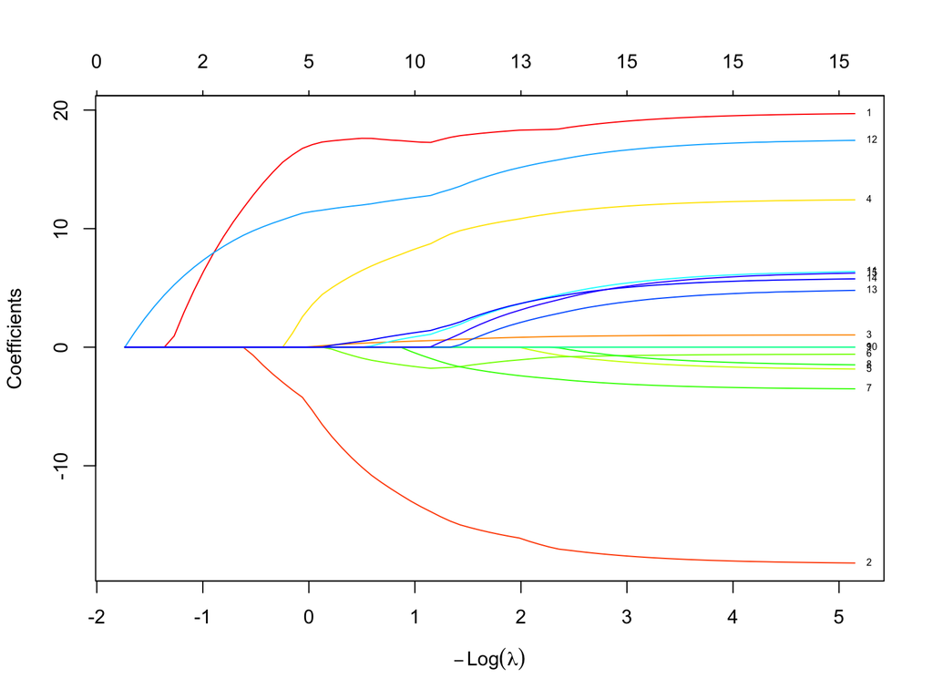

```r
# Get output for each LASSO model
all_lassos <- final_lasso %>%
  extract_fit_parsnip() %>%
  pluck("fit")

# Plot coefficient paths as a function of lambda
plot(all_lassos, xvar = "lambda", label = TRUE, col = rainbow(20))
```

```r
# Codebook for which variables the numbers correspond to
rownames(all_lassos$beta)
```

```
 [1] "danceability"     "energy"           "loudness"         "speechiness"
 [5] "acousticness"     "instrumentalness" "liveness"         "valence"
 [9] "tempo"            "duration_ms"      "genre_latin"      "genre_pop"
[13] "genre_r.b"        "genre_rap"        "genre_rock"
```

Note that our chosen $\lambda$ falls near 0 on the x-axis:

```r
log(parsimonious_penalty$penalty)
```

```
[1] -0.06977531
```

- Var 1 = `danceability`
- Var 12 = `genre_pop`
- Var 2 = `energy`
- Var 4 = `speechiness`
- Var 3 = `loudness`
- Var 14 = `genre_rap`

### Part d

Summarize the key themes of this plot in your own words. IMPORTANT: You don’t need to write this out but be sure to convince yourself that you understand what each number and line on this plot represents.

**Answer**

Will vary but the answer should:

- address shrinkage of coefficients toward / to 0 as $\lambda$ increases
- note either some more persistent predictors (eg: genre categories, danceability, energy) or some less persistent predictors.

## 4: finalizing our analysis

Results for the least squares alternative to the LASSO are included below (you don’t have to recreate these):

```r
ls_model %>%
  tidy()
```

```
# A tibble: 16 × 5
   term                estimate std.error statistic  p.value
   <chr>                  <dbl>     <dbl>     <dbl>    <dbl>
 1 (Intercept)       51.3       7.70          6.66  6.01e-11
 2 genrelatin         6.53      2.49          2.63  8.82e- 3
 3 genrepop          17.6       2.19          8.04  4.26e-15
 4 genrer&b           4.95      3.14          1.57  1.16e- 1
 5 genrerap           5.88      2.24          2.62  8.92e- 3
 6 genrerock          6.42      2.33          2.76  5.91e- 3
 7 danceability      19.8       5.08          3.90  1.08e- 4
 8 energy           -18.3       5.52         -3.31  9.86e- 4
 9 loudness           1.04      0.310         3.37  8.08e- 4
10 speechiness       12.5       8.29          1.51  1.32e- 1
11 acousticness      -1.93      3.52         -0.547 5.84e- 1
12 instrumentalness  -0.563     4.10         -0.137 8.91e- 1
13 liveness          -3.56      5.38         -0.662 5.08e- 1
14 valence           -1.59      3.15         -0.505 6.14e- 1
15 tempo              0.00707   0.0231        0.306 7.60e- 1
16 duration_ms        0.0000107 0.0000107     1.00  3.18e- 1
```

```r
ls_cv %>%
   collect_metrics()
```

```
# A tibble: 1 × 6
  .metric .estimator  mean     n std_err .config
  <chr>   <chr>      <dbl> <int>   <dbl> <chr>
1 mae     standard    12.1    10   0.348 pre0_mod0_post0
```

### Part a

Keeping in mind the music executive’s goals, which model would you pick: the least squares model or your final LASSO model? *Explain.* Support your explanation with specific context and results.

**Answer**

I would pick the LASSO. It’s simpler and has only a slightly worse predictions (a CV MAE of roughly 12.5 vs roughly 12.1). If you argue for the least squares, you need to also argue that this jump in prediction error is too big.

*It is worth noting that if you pick LASSO, you may need to be prepared to explain to the music executive how LASSO differs from least squares. Although the model we end up with is simpler, the approach itself is somewhat more complicated. This is not necessarily a reason to choose one approach over the other, just something to be aware of!*

### Part b

Is your chosen model *wrong*? (It’s ok if it is – we won’t fix it now.) Support your answer with appropriate evidence.

**Answer**

**COMMENT:** The residual plot looks fairly good. There might be a bit of heterogeneity in our residuals, but it isn’t a strong pattern. One thing you might note is among songs that we predict popularity to be around 60, we tend to underpredict (positive residuals); that might be worth exploring further. But overall, our model doesn’t seem too wrong.

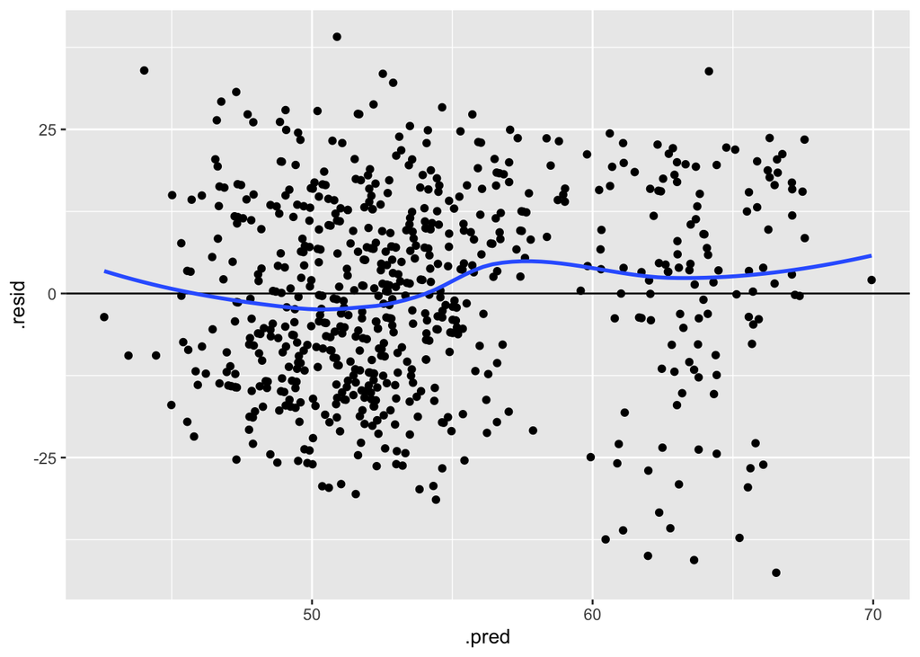

```r
final_lasso %>%
  augment(new_data = music_sub) %>%
  mutate(.resid = popularity - .pred) %>% # For Lasso, you need to calculate resid
  ggplot(aes(x = .pred, y = .resid)) +
    geom_point() +
    geom_hline(yintercept = 0) +
    geom_smooth(se = FALSE)
```

### Part c

Based on the results of your chosen model, offer the music executive some advice on how to write the most popular song possible.

- Use complete sentences. Think of the executive as your client.
- Don’t get into rigorous coefficient interpretations! This wouldn’t be useful for the executive. Simply focus on what *increases* popularity and what *decreases* popularity.

**Answer**

My advice: write a pop song with strong danceable properties, low energy, and some speechiness.

## 5: resource reflection

List the resouces you used to complete this assignment (e.g. office hours, textbook, Gen AI, etc.)

Write 3-5 sentences about which resources were the most useful in helping you complete the assignment.

**Answer**

Answers will vary, but students should list the resouces they used to complete this assignment (e.g. office hours, textbook, Gen AI, etc.) and write 3-5 sentences about which resources were the most useful in helping them complete the assignment.

## 6: learning reflection

We now find ourselves at the end of the our second unit! This is a good moment to pause, organize your notes, and reflect on how things have been going.

This is the first of four learning reflections that you will complete this term.

Follow the instructions below:

1. Create a Google Doc, called *STAT 253 - Learning Reflection Journal - Your Name*.
2. Share this doc, **with editing access**, with your instructor.
3. Create a section titled *Reflection 1*.
4. Copy-paste the reflection prompts, below, into that document.
5. Type your answers to those prompts into that reflection journal. (Suggestion: use an alternate font color to clearly distinguish your responses from the prompts!)

Your reflection is due at the same time as this homework. Before you submit your final homework HTML, please double-check that your reflection journal has been updated **AND** that your instructor has been added as an editor.

**Reflection 1 Prompts**

1. **Scavenger Hunt / Getting Organized**  
   Locate, open, and organize* the following:
   - the course website
   - the course syllabus
   - the course moodle page
   - the course textbook (ISLR)
   - your feedback spreadsheet
   - the homeworks that you have completed thus far
   - the quizzes that you have completed thus far
   - the group assignments you have completed thus far
   - your quarto templates/notes from in-class exercises
   - any other notes that you have taken while preparing for class (eg watching lecture videos, reading the textbook), during class time, or studying

   If you don’t already have a Stat 253 folder on your computer, make one. Put all of your files from this class there, and create sub-folders for different types of assignments (eg HW, in-class activities, group assignments). Bookmark any webpages that you think you might reference later. In general, think about what resources you might want to be able to access again in the future and make it as easy as possible for your future self to find them.

   Once you have completed the tasks above, include a screenshot or two to show off your organization system and move on to the next question.
2. **Engagement**  
   In **1–2 paragraphs**, write a short reflection about your *engagement* with the course thus far. Here are some prompts to consider (you don’t need to address all of them!):
   - Class Time:
     - Have you regularly attended class sessions?
     - Do you arrive on time and stay for the full class?
     - Are you actively present during class (eg: not on your phone, not working on other courses, etc)?
   - Preparation:
     - Do you watch the full videos?
     - Do you take notes while watching the videos?
     - Do you complete the checkpoint thoughtfully?
     - Do you stay updated on Slack?
     - When you have questions, do you ask them on Slack or in OH?
     - What else do you do to prepare for class each day?
   - Practice:
     - What resources do you review before (or while) working on homework?
     - Have you submitted all homework assignments on time?
     - How many times have you used an extension?
     - When you have homework questions, do you ask them on Slack or in OH?
     - Have you been actively reviewing your HW feedback when it is posted?
   - Is there anything you want to try differently with respect to engagement during the next few weeks of the semester?
3. **Collaboration**  
   In addition to learning new machine learning algorithms, this course is also designed to help you practice and develop “general” skills that are important for future coursework and careers in statistics, data science, and many other fields. These include: computational thinking, data communication, collaboration, ethical thinking, and reflection. We’ll focus on *collaboration* for this question.

   Review the learning goals on the course website related to this general skill (see Course Logistics > Learning Goals > General Skills > Collaborative Learning).

   Then, write **1–2 paragraphs** addressing the following:
   - What progress have you made toward the *collaborative learning* learning goals so far this semester?
   - What you have found most helpful in facilitating that progress?
   - Have you experieced any barriers to making progress on these goals?
   - Describe at least one goal related to further practicing and developing this skill in the next portion of the semester.
4. **Follow-Up**  
   Would it be helpful to follow up with the instructor to talk more about this reflection? Select one: **Yes, I’d like the instructor to follow up with me** / **No, I’m fine for now**

**Answer**

Instructors will grade this question

## 7: Spotify + R

**This exercise will not be graded.**

You can directly play around with Spotify’s API within R! If you’re curious, follow the instructions [here](https://github.com/charlie86/spotifyr) to import data into R related to any Spotify play list, artist, genre, etc.

**Answer**

NOT GRADED

## Footnotes

[^1]: Take Bayesian Stat or Correlated Data to learn about incorporating artist and album name!